სმკმ: მეხუთე შეხვედრა

# სოციალურ მეცნიერებათა კვლევის მეთოდები

დავით სიჭინავა  
1 ნოემბერი, 2018 წ.

მეხუთე შეხვედრა

### დღევანდელი შეხვედრის გეგმა

- ლექცია: ექსპერიმენტული დიზაინი
- შუალედური გამოცდა

### Bertrand & Mullainathan (2004)

- არსებობს თუ არა რასობრივი დისკრიმინაცია დასაქმების სფეროში?

### Bertrand & Mullainathan (2004)

| ცვლადი | აღწერა |
| --- | --- |
| firstname | აპლიკანტის სახელი |
| sex | სქესი |
| race | რასა |
| call | შეეხმიანენ თუ არა აპლიკანტს ტელეფონზე |

### კაუზალური (მიზეზშედეგობრივი) კავშირი

- კოვარიაცია
- ყალბი მიმართების შემცირება
- მოვლენათა დროში თანმიმდევრობის დადგენა

### შემთხვევითი განაწილების (რანდომიზაციის) როლი

- ჰომოგენური ჯგუფების შექმნა - განსხვავება მხოლოდ ექსპერიმენტულ პირობას შეიძლება, დავაბრალოთ
- შერჩევის შეცდომა (Selection bias)
- დიდ რიცხვთა კანონი

### ჰიპოთეტური ფაქტები

- ჰიპოთეტური ფაქტები (კონტრფაქტები)
  - რა მოხდებოდა, რომ…
- დევიდ ჰიუმი

### ნეიმან-რუბინ-ჰოლანდის მიზეზშედეგობრივი სტატისტიკური დასკვნის მოდელი

- ყოველი \( i \)-თვის, \( T{i} \) ექსპერიმენტის მიზეზედეგობრივი ეფექტი განიმარტება, როგორც \( Y_{i}(1) - Y_{i}(0) \), სადაც \( Y_{i}(1) \) წარმოადგენს შედეგს, რომელსაც ექსპერიმენტულ ჯგუფში მივიღებდით, ხოლო \( Y_{i}(0) \) - შედეგს, რომელიც საკონტროლო ჯგუფში გვექნებოდა
- მიზეზშედეგობრივი სტატისტიკური დასკვნის ფუნდამენტური პრობლემა

### ჰიპოთეტური ფაქტები

> > მიზეზშედეგობრივი სტატისტიკური დასკვნის მიზანი ჰიპოთეტური ფაქტების პროგნოზია

### კვლევის დიზაინი

- შედარება
- მანიპულაცია
- კონტროლი
- განზოგადება

### კონტროლი

- შიდა ვალიდობა
- გათანაბრება
- რანდომიზაცია
- საკონტროლო ჯგუფი

### განზოგადება

- გარე ვალიდობა
- რეპრეზენტატულობა
- წინააღმდეგობრივი პირობები

### კლასიკური ექსპერიმენტული დიზაინი

[figure not shown]

### კლასიკური ექსპერიმენტული დიზაინი

- ექსპერიმენტული და საკონტროლო ჯგუფი
- ტესტამდელი (პრეტესტული) და ტესტის შემდგომი (პოსტტესტური) გაზომვა
- ცდისპირთა *შემთხვევითი* განაწილება

### რანდომიზებული კონტროლირებული ექსპერიმენტები

| შემთხვევათა რ-ნობა | პროპორცია | სტანდარტული შეცდომა |  |
| --- | --- | --- | --- |
| კონტროლი | 55 | 0.3353659 | 0.0369792 |
| პირდაპირი წესით არჩეული პრეზიდენტი | 58 | 0.3536585 | 0.0374481 |
| პარლამენტის მიერ არჩეული პრეზიდენტი | 51 | 0.3109756 | 0.0362566 |
| სულ | 164 |  |  |

### რანდომიზებული კონტროლირებული ექსპერიმენტები

| ჯგუფი (საყრდენი: საკონტროლო ჯგუფი) |  |  |  |
| --- | --- | --- | --- |
|  | პირდაპირი წესით არჩეული პრეზიდენტი | -1.363636 | -9.975612 |
|  | პარლამენტის მიერ არჩეული პრეზიდენტი | -21.27273 | (10.24279)** |
| მემარჯვენე-მემარცხენე სპექტრი |  | 1.818182 | (0.6586654)*** |
| პოლიტიკური ცოდნა |  | -10.36364 | -10.85779 |
| თავისუფალი წევრი |  | 2 | -38.20426 |
| ფსევდო R2 |  | 0.0901 |  |
| დაკვირვებათა რ-ნობა |  | 157 |  |

### რანდომიზებული კონტროლირებული ექსპერიმენტები

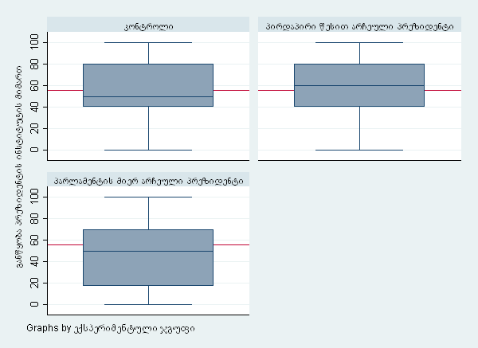

### სოლომონის ოთხჯგუფიანი დიზაინი

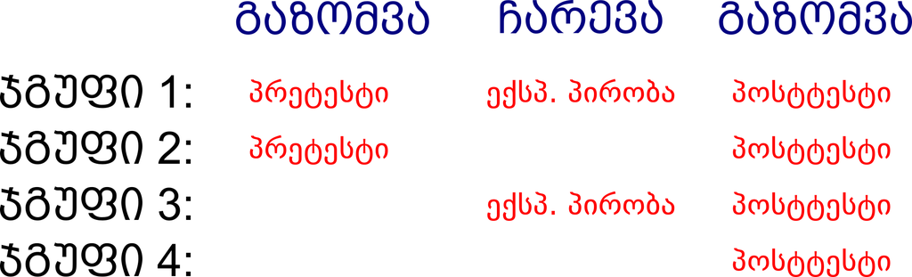

### პოსტტესტური დიზაინი

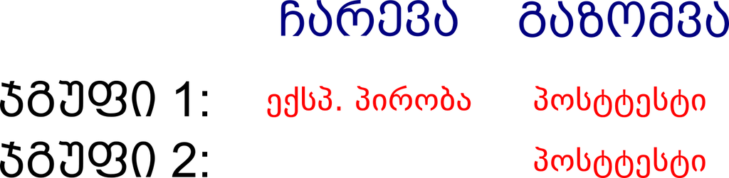

### დიზაინი გამოტოვებული შედეგისთვის

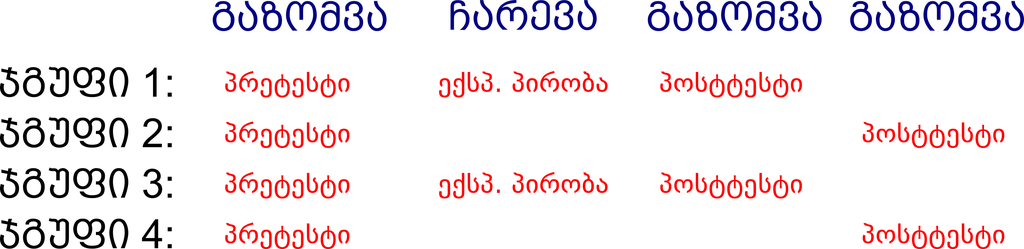

### ფაქტორული დიზაინი

- ორი ან მეტი *დამოუკიდებელი ცვლადი*

### რანდომიზაცია?

- ჯგუფთაშორისი დიზაინი
- კვაზიექსპერიმენტული დიზაინი

### ჯგუფთაშორისი დიზაინი

- ორ ან მეტ ჯგუფს შორის განსხვავების შესწავლა

### კვაზიექსპერიმენტული დიზაინი

- კონტრასტული ჯგუფების დიზაინი
- დაგეგმილი ვარიაციის დიზაინი
- პანელი
- დროთა სერიის (დროის მწკრივების) დიზაინი
- კონტროლის სერიის დიზაინი
- სინთეტური კონტროლის დიზაინი

### კვაზიექსპერიმენტული დიზაინი: Abadie, Diamond & Hainmueller, 2010

- კალიფორნიის ,,კანონპროექტი-99''
- საკანონმდებლო რეგულაციის გავლენა სიგარეტის გაყიდვებზე

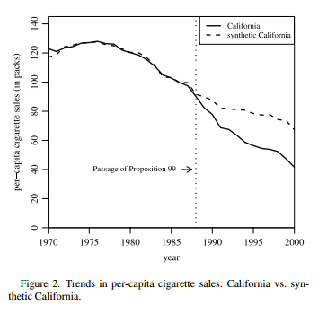

### კვაზიექსპერიმენტული დიზაინი: Abadie, Diamond & Hainmueller, 2010

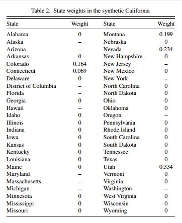

### Card & Krueger (1994)

- მინიმალური ხელფასის ცვლილება
- იმოქმედა თუ არა ხელფასის მომატებამ დასაქმებაზე?

### Card & Krueger (1994)

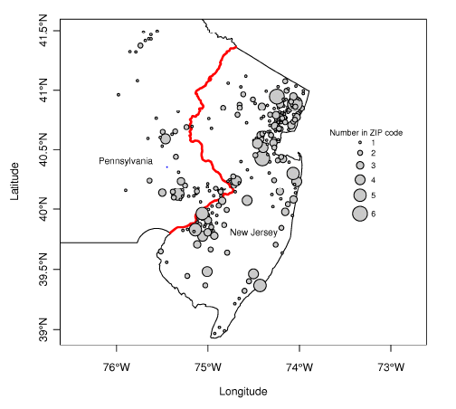

### შუალედური გამოცდა

- ნაჩმიასი და ნაჩმიასი, გვ. 30-41
- ლიტლი, გვ. 4-12
- ნაჩმიასი და ნაჩმიასი, გვ. 393-427
- ნაჩმიასი და ნაჩმიასი, გვ. 121-141
- ნაჩმიასი და ნაჩმიასი, გვ. 42-46
- ნაჩმიასი და ნაჩმიასი, გვ. 55-89
- ნაჩმიასი და ნაჩმიასი, გვ. 151-222

[figure not shown]